# Tutorial on Bayesian Statistics: Replicating Sections of BDA3

First we compute, as a rough approximation of the parameters, the ML estimates.

```r # Data x = c(-0.86, -0.30, -0.05, 0.73) y = c(0,1,3,5) n = rep(5,4)

# ML estimation mlfit <- glm( cbind(y, n-y) ~ x, family = binomial) mlfit$coefficients = round(mlfit$coefficients*1000)/1000 res1 = paste(paste(“(”,mlfit$coefficients[1], sep=""), paste(mlfit$coefficients[2],“)”, sep=“”), sep=“,”) ```

With the estimates $(\hat{\alpha},\hat{\beta}) = (0.847,7.749)$.

Now we will simulated values of $\alpha$ and $\beta$ from the posterior distribution. The approach is as follows.

* (i) Build a grid for all possible values of $\alpha$ and $\beta$. Although this can be the whole real line, we use the ML estimates and some trial and error to restrict the space to $\alpha \in [-5,10]$ and $\beta \in [-10,40]$.

`r alpha = seq(-5,10,.1) beta = seq(-10,40,1)`

* (ii) Compute the posterior density (equation \ref{post.1}) over the whole grid and normalize it to 1.

```r post.a = function(a,b,x,y,n) { post = 1 for (i in 1:length(y)) { post = post * ( ((inv.logit(a+b*x[i]))<sup>y[i])*((1-inv.logit(a+b*x[i]))</sup>(n[i]-y[i])) ) } post }

post.dens = outer(alpha,beta,function(x1,x2) post.a(x1,x2,x,y,n)) post.dens = post.dens/sum(post.dens) ```

* (iii) Inspect the density using a contour plot (here we are looking for some indication that we are covering all the possible domain)

`r contours <- seq(min(post.dens), max(post.dens) , length=10) par(mar = rep(2, 4)) contour(alpha, beta, post.dens,levels=contours, xlab=expression(alpha), ylab=expression(beta), xlim=c(min(alpha),max(alpha)) , ylim=c(min(beta),max(beta)), drawlabels=FALSE, main="Contour plot of joint posterior")`

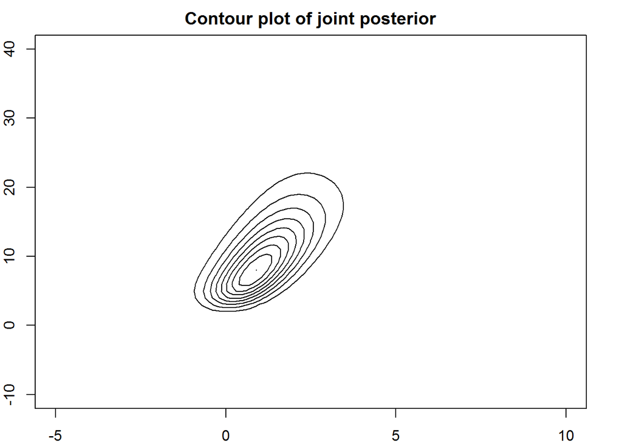

* (iv) Compute the marginal posterior of $\alpha$ by summing over all $\beta$ for each value of $\alpha$. Notice so far that we had only compute the probability distribution of $\alpha$ and $\beta$. Is not until this point where we would be able to do things like compute the mean, median and CI’s of these parameters.

`r samps = 1000 alpha.dens = apply(post.dens ,1, sum)` * (v) For $s = 1 \dots 1000$: a. Draw $\alpha^{s}$ from its marginal posterior.

`r s.alpha = sample(alpha,samps, replace=TRUE, prob = alpha.dens)` b. Draw $\beta^{s}$ from $p(\beta|\alpha,y)$ for each value of $\alpha^{s}$

`r #Select the colum of the joint density corresponding to a specific value of alpha (p(beta|alpha)) cond.beta = function(x) { post.dens[which(alpha == s.alpha[x]),] } #Sample a value of beta according the the conditional probatility above s.beta = sapply(1:samps,function(x) sample(beta,1,replace=TRUE,prob=cond.beta(x)))` c. For each sample values of $\alpha$ and $\beta$ add a uniform random jitter centered at zero with with equal to the grid spacing. This will make the simulation draws more continuous. Plot the sampled values.

`r s.beta = s.beta + runif(length(s.beta),-.5,.5) s.alpha = s.alpha + runif(length(s.alpha),-.05,.05) plot(s.alpha, s.beta, xlab=expression(alpha^s), ylab=expression(beta^s), xlim=c(min(alpha),max(alpha)) , ylim=c(min(beta),max(beta)), main="Scatter Plot of Sample Draws of alpha and beta")`

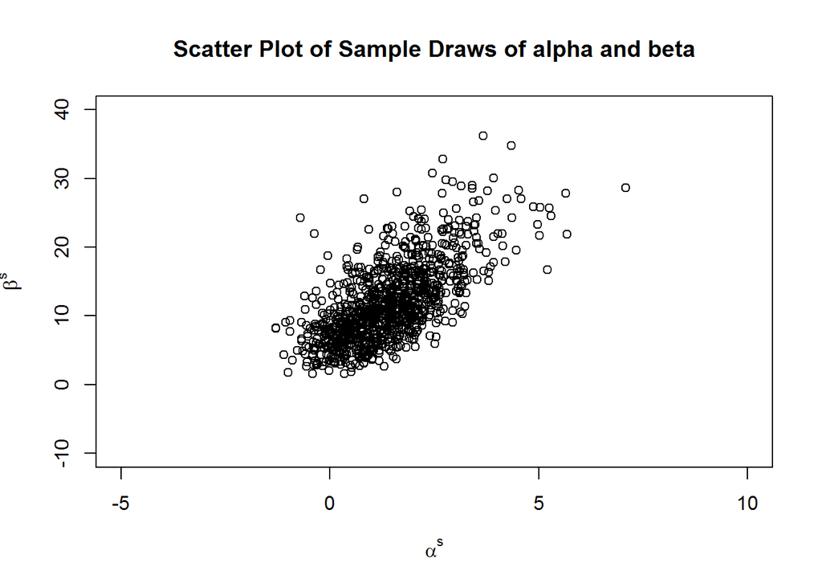

The final result are two vectors $(\{\alpha^{s}\}), (\{\beta^{s}\})$, that represent probability distribution of each parameter.

# 4 - Description with my own words, of the fully Bayesian analysis of conjugate hierarchical models described in section 5.3 of BDA (pg 108 - 113)

The overall goal of hierarchical models is **to describe a statistical (uncertain) phenomena where are multiple parameters involved and exists a dependence structure**.

The analysis described here builds on what we just did in the example above. For this purpose we enumerate the steps followed, now in a more general notation.

1. Compute the joint posterior probability distribution of all the parameters conditional on the data and a prior distribution of those parameters (in the example above we use a non-informative prior). 2. Compute the marginal posterior of one parameter ($p(\theta_{2}|y)$) by summing the joint posterior over all the possible values of the other parameter ($\theta_{1}$). 3. Compute the marginal of the other parameter ($p(\theta_{1}|y)$) using the following identity:

$\begin{aligned} p(\theta_{1}|y) = \int p(\theta_{1}|\theta_{2},y) p(\theta_{2}|y) d\theta_{2} \approx p(\theta_{1}|\theta^{s}_{2},y) \end{aligned}$ Where $\theta^{s}_{2}$ is a random draw using $p(\theta_{2}|y)$ (the justification for this last step is in section 2 of this document).